# Effect of Sever Weather Events on public health and economy

Storms and other severe weather events can cause both public health and economic problems for communities and municipalities. Many severe events can result in fatalities, injuries, and property damage, and preventing such outcomes to the extent possible is a key concern.

In this report, we will explore the effects of different type of weathers on both population health and economic consequences. In summary, our findings are as followed:

- Tornado has the greatest impact on population health with a total fatalities of 5,633
- Flood has the greatest economic consequences with a total property and crop damages at around USD 150 billions.

## Data Processing

### Loading data

To begin, we first obtain the data from the U.S. National Oceanic and Atmospheric Administration’s (NOAA) storm database. The data is compressed in bzip2 algorithm, and we will have to unzip it first to use the data and read it into a dataframe.

```r
download.file("https://d396qusza40orc.cloudfront.net/repdata%2Fdata%2FStormData.csv.bz2",destfile="noaa.csv.bz2",method="curl")
bunzip2("noaa.csv.bz2", "noaa.csv", remove = FALSE)
data <- read.csv("noaa.csv")
```

### Extracting columns that are needed

To reduce the use of memory, we extract only columns we need regarding health and economy. They are

1. “BGN_DATE”: The date of the severe weather record
2. “EVTYPE”: The type of weather
3. “FATALITIES”: The no. of fatalities as a result of the severe weather
4. “PROPDMG”: The property damage resulted from the severe weather
5. “PROPDMGEXP”: The order of magnitude for the property damage
6. “CROPDMG”: The crop damage resulted from the severe weather
7. “CROPDMGEXP”: The order of magnitude for the crop damage

```r
needed.cols <- c("BGN_DATE","EVTYPE","FATALITIES","PROPDMG","PROPDMGEXP","CROPDMG","CROPDMGEXP")
data.subset <- data[needed.cols]
remove(data) #to save memory space we remove the data variable
```

### Extracting years from date

We extract the year from the dataset using `as.Date` function. This data can be use to plot by years if needed.

```r
data.subset[,"BGN_DATE"] = as.Date(data.subset[,"BGN_DATE"],format="%m/%d/%Y %H:%M:%S")
data.subset[,"BGN_YEAR"] = format(data.subset[,"BGN_DATE"],"%Y")
```

### Converting the to actual figures

The damages recorded for the property and crop has to be multiple by the magnitude to get the actual figures.

```r
###1. For property damage
#add a new multiplier column
data.subset$PROPDMGMULTIPLIER <- as.character(data.subset$PROPDMGEXP)

data.subset[(tolower(data.subset[,"PROPDMGEXP"]) == "k"),]$PROPDMGMULTIPLIER <- "3"
data.subset[(tolower(data.subset[,"PROPDMGEXP"]) == "m"),]$PROPDMGMULTIPLIER <- "6"
data.subset[(tolower(data.subset[,"PROPDMGEXP"]) == "b"),]$PROPDMGMULTIPLIER <- "9"
data.subset[(tolower(data.subset[,"PROPDMGEXP"]) == "h"),]$PROPDMGMULTIPLIER <- "2"

data.subset$PROPDMGMULTIPLIER <- as.numeric(data.subset$PROPDMGMULTIPLIER)
data.subset[(is.na(data.subset[,"PROPDMGMULTIPLIER"])),]$PROPDMGMULTIPLIER <- 0

#Get the actual property damage
data.subset$PROPDMGACTUAL <- data.subset$PROPDMG * 10^data.subset$PROPDMGMULTIPLIER


###2. For crop damage
#add a new multiplier column
data.subset$CROPDMGMULTIPLIER <- as.character(data.subset$CROPDMGEXP)

data.subset[(tolower(data.subset[,"CROPDMGEXP"]) == "k"),]$CROPDMGMULTIPLIER <- "3"
data.subset[(tolower(data.subset[,"CROPDMGEXP"]) == "m"),]$CROPDMGMULTIPLIER <- "6"
data.subset[(tolower(data.subset[,"CROPDMGEXP"]) == "b"),]$CROPDMGMULTIPLIER <- "9"

data.subset$CROPDMGMULTIPLIER <- as.numeric(data.subset$CROPDMGMULTIPLIER)
data.subset[(is.na(data.subset[,"CROPDMGMULTIPLIER"])),]$CROPDMGMULTIPLIER <- 0

#Get the actual crop damage
data.subset$CROPDMGACTUAL <- data.subset$CROPDMG * 10^data.subset$CROPDMGMULTIPLIER


#Sum both crop and property damages
data.subset$TOTALDMG <- data.subset$CROPDMGACTUAL + data.subset$PROPDMGACTUAL
```

We will then sum up the total fatalities and damages (property and crop) to get the final aggregated table that we need.

```r
damages <-aggregate(TOTALDMG ~ EVTYPE,data = data.subset, FUN="sum", na.rm=TRUE)
fatalities <-aggregate(FATALITIES ~ EVTYPE,data = data.subset, FUN="sum", na.rm=TRUE)
```

## Results

### Most harmful severe weather type to population health

We plot the top 15 weather types by number of fatalities below. *Tornado* is the highest cause for fatalities totalling at 5633. Hence it is the most harmful severe weather type to population health.

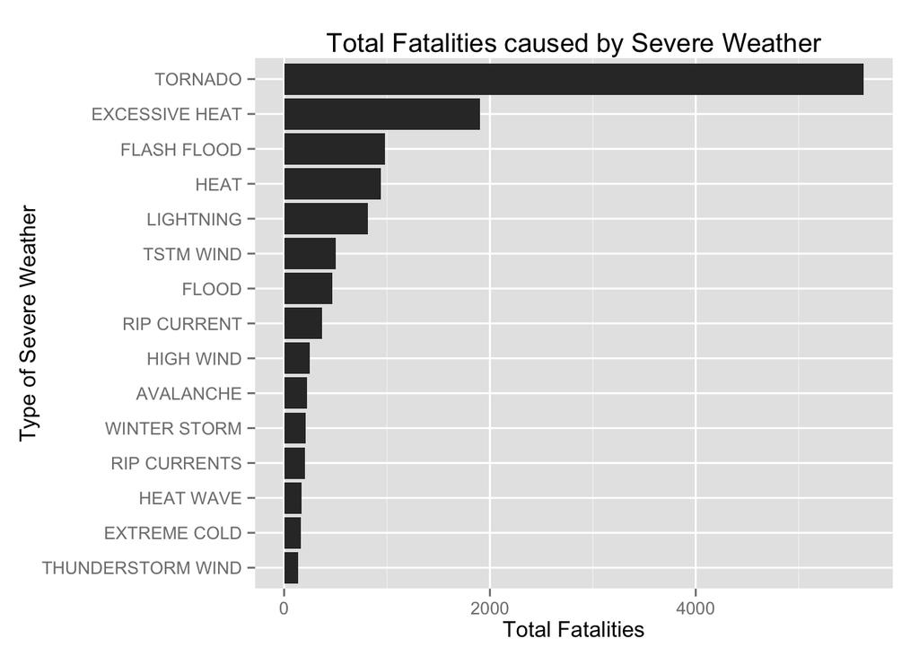

### Most harmful severe weather type to economy

Next, we plot the top 15 most damaging weather type to the economy in the barplot below. *Flood* is the most damaging to the economy totalling at USD 150 billions.

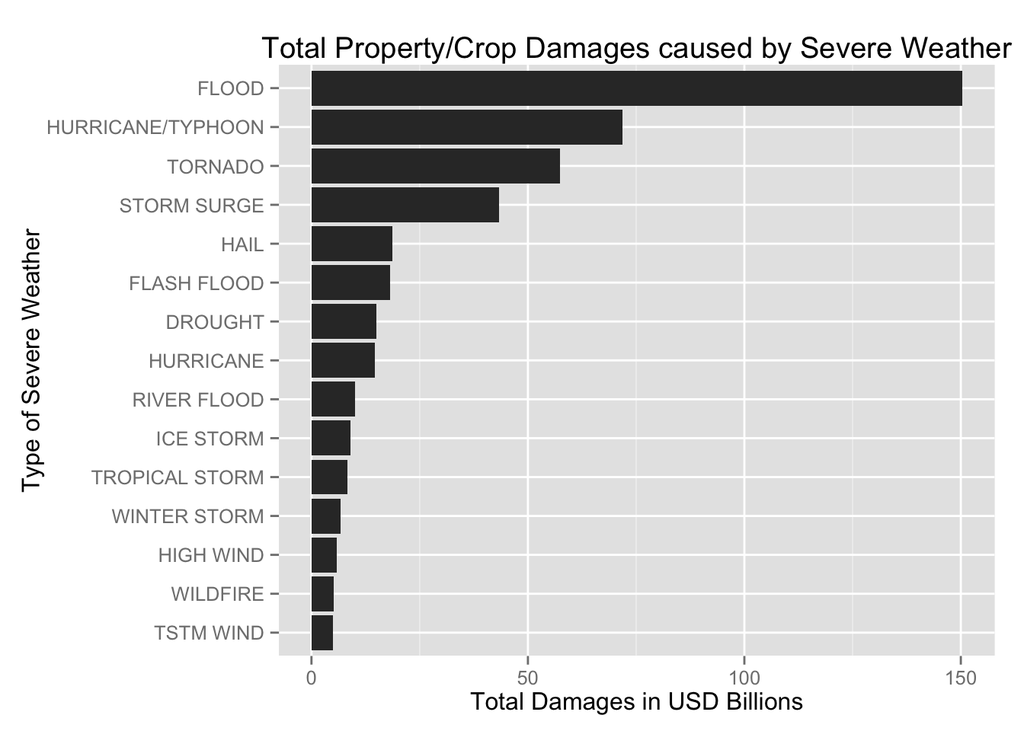

###### Prepared by Jax Xie Jianxin 2015